# Probabilidad con R

Dana Amador

2026-09-22

# Actividad 1: Reconoce la relación entre eventos

Supón que $P(A)=0.40$, $P(B)=0.30$ y $P(A\cap B)=0.12$.

1. Comprueba si $A$ y $B$ son independientes.
   $$\begin{align*}
   P(A\cap B) &= 0.12 \\
   &=(0.30)(0.40)\\
   &=P(A)P(B)\\
   \Rightarrow P(A\cap B) &= P(A)P(B)
   \end{align*}$$
   $\therefore A$ y $B$ son independientes
2. Calcula $P(A|B)$.
   $$\begin{align*}
   P(A|B) &= \frac{P(A \cap B)}{P(B)}\\
   &= \frac{0.12}{0.30}\\
   &= 0.40\\
   &= P(A)
   \end{align*}$$
   $\therefore P(A|B)=P(A)$
3. Explica qué información aporta la condición B sobre la probabilidad de A.

No aporta ninguna información, puesto que son independientes. Esto se puede ver en el punto 2, ya que la ocurrencia de $B$ no afecta la probabilidad de ocurrencia de $A$.

# Actividad 2: Explora la binomial

Utiliza $X \sim Binomial(20,0.30)$.

```r
n <- 20
p <-0.3
```

1. Calcula $P(X=5)$.

   ```r
   resultado = dbinom(5,n,p)
   print(resultado)
   ```

   ```
   ## [1] 0.1788631
   ```

2. Calcula $P(X\leq5)$.

   ```r
   resultado = pbinom(5,n,p,TRUE)
   print(resultado)
   ```

   ```
   ## [1] 0.4163708
   ```

3. Calcula $P(X>5)$.

   ```r
   # P(X > 5) =  1 - P(X <= 5)
   resultado = 1 - pbinom(5,n,p,TRUE)
   print(resultado)
   ```

   ```
   ## [1] 0.5836292
   ```

4. Calcula $P(4\leq X \leq 8)$.

   ```r
   # P(4 <= X <= 8) = P(X <= 8) - P(X < 4) = P(X <= 8) - P(X <= 3)
   resultado = pbinom(8,n,p,TRUE) - pbinom(3,n,p,TRUE)
   print(resultado)
   ```

   ```
   ## [1] 0.7795817
   ```

5. Grafica la distribución.

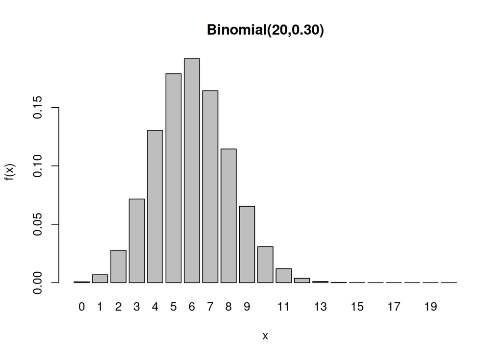

   ```r
   x <- 0:n
   prob <- dbinom(x, n, p)

   barplot(
     prob,
     names.arg = x,
     xlab = "x",
     ylab = "f(x)",
     main = "Binomial(20,0.30)"
   )
   ```

6. Cambia $p$ a $0.5$ y vuelve a graficar.

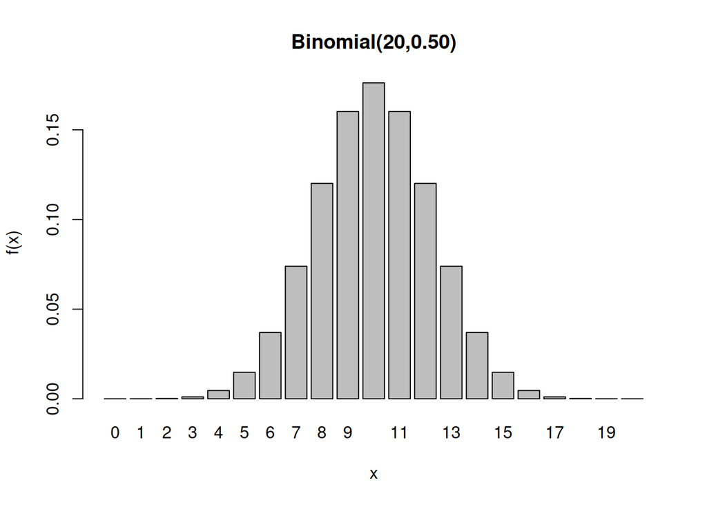

   ```r
   p <- 0.5
   x <- 0:n
   prob <- dbinom(x, n, p)

   barplot(
     prob,
     names.arg = x,
     xlab = "x",
     ylab = "f(x)",
     main = "Binomial(20,0.50)"
   )
   ```

7. Describe qué cambia en la distribución.

   Cuando $p=0.3$ vemos que la gráfica se concentra al inicio de los valores de $x$, mientras que cuando $p=0.5$ se concentran más bien en el centro. Cuando $p=0.5$ la moda coincide con la mediana.

# Actividad 3: Poisson

Para $X \sim Poisson(4)$

```r
lambda <- 4
```

1. Calcula $P(X=2)$.

   ```r
   resultado <- dpois(2,lambda)
   print(resultado)
   ```

   ```
   ## [1] 0.1465251
   ```

2. Calcula $P(X\leq 2)$.

   ```r
   resultado <- ppois(2,lambda,TRUE)
   print(resultado)
   ```

   ```
   ## [1] 0.2381033
   ```

3. Calcula $P(X > 8)$.

   ```r
   # P(X > 8) = 1 - P(X <= 8)
   resultado <- 1 - ppois(8,lambda,TRUE)
   print(resultado)
   ```

   ```
   ## [1] 0.02136343
   ```

4. Calcula $P(3 \leq X \leq 6)$.

   ```r
   # P(3 <= X <= 6) = P(X <= 6) - P(X < 3) = P(X <= 6) - P(X <= 2)
   resultado <- ppois(6,lambda,TRUE) - ppois(2,lambda,TRUE)
   print(resultado)
   ```

   ```
   ## [1] 0.6512227
   ```

5. Grafica la distribución

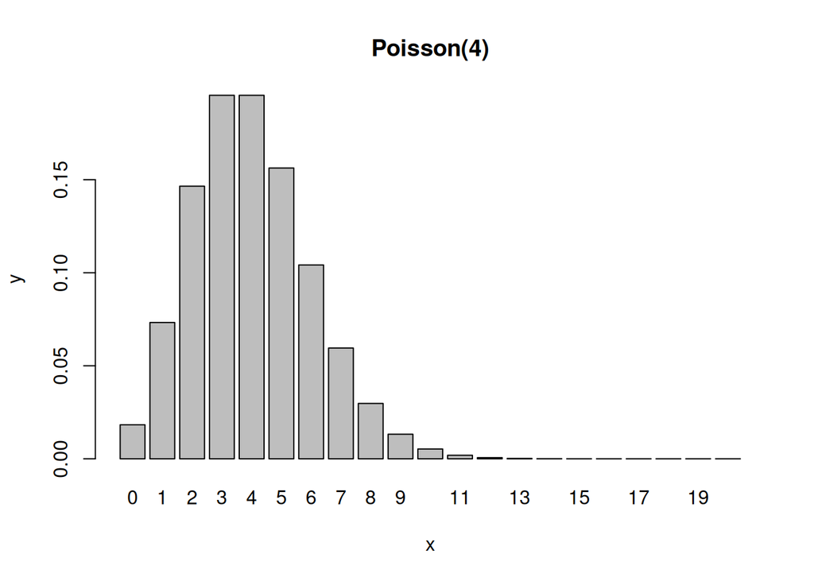

   ```r
   x <- 0:20
   prob <- dpois(x,lambda)

   barplot(
     prob,
     names.arg = x,
     xlab = "x",
     ylab = "y",
     main = "Poisson(4)"
   )
   ```

6. Cambia $\lambda$ a $8$. ¿Qué observas?

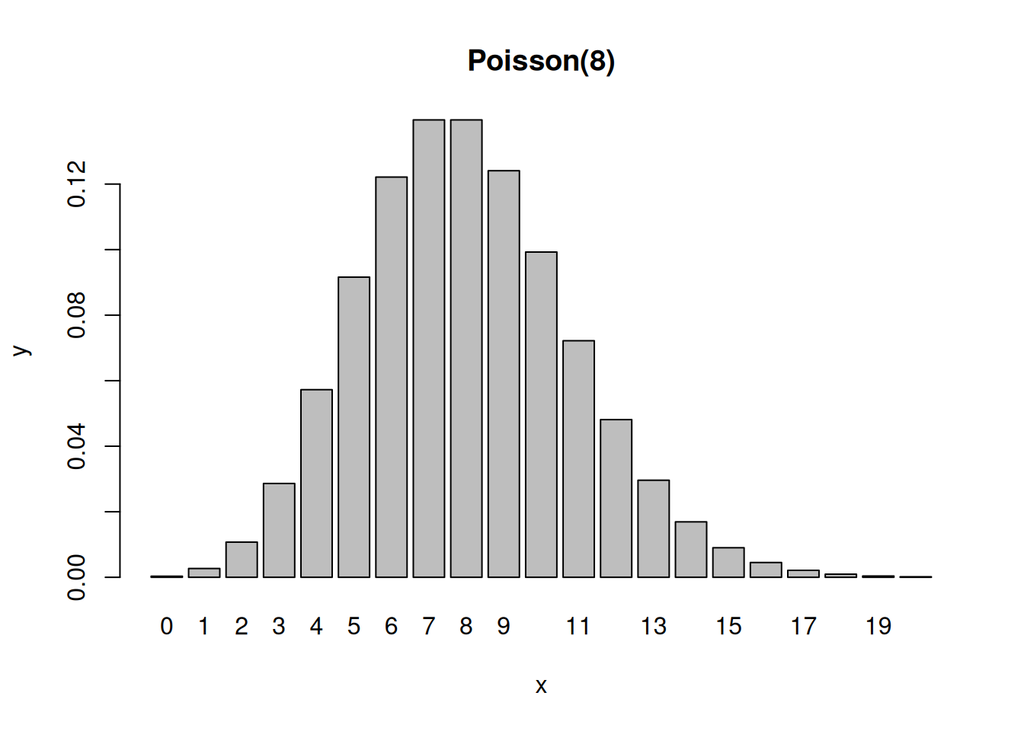

   ```r
     lambda <- 8
     x <- 0:20
     prob <- dpois(x,lambda)

     barplot(
     prob,
     names.arg = x,
     xlab = "x",
     ylab = "y",
     main = "Poisson(8)"
   )
   ```

# Actividad 4: Uniforme

Para $X \sim U(420,460)$:

```r
min = 420
max = 460
```

1. Calcula $P(X<430)$.

   ```r
   resultado = punif(430,min,max,TRUE)
   print(resultado)
   ```

   ```
   ## [1] 0.25
   ```

2. Calcula $P(425<X<435)$.

   ```r
   # P(425 < X < 435) = P(X < 435) - P(X <= 425)
   resultado = punif(435,min,max,TRUE) - punif(425,min,max,TRUE)
   print(resultado)
   ```

   ```
   ## [1] 0.25
   ```

3. Calcula $P(X>450)$.

   ```r
   # P(X > 450) = 1 - P(X < 450)
   resultado = 1 - punif(450,min,max,TRUE)
   print(resultado)
   ```

   ```
   ## [1] 0.25
   ```

4. Representa gráficamente la densidad.

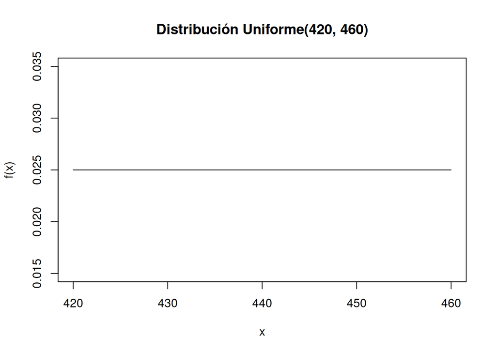

   ```r
   a <- 420
   b <- 460
   x <- seq(a, b, length.out = 500)

   plot(
     x,
     dunif(x, min = a, max = b),
     type = "l",
     xlab = "x",
     ylab = "f(x)",
     main = "Distribución Uniforme(420, 460)"
   )
   ```

5. Explica por qué la probabilidad puede interpretarse como un área.

Porque para calcularla es necesario utilizar una integral, la cual representa geométricamente el área bajo la curva.

# Actividad 5: Normal

Sea $X \sim N,(45,8^2)$.

```r
mu <- 45
sigma <- 8
```

1. Calcula $P(X \leq 58)$

   ```r
     resultado <- pnorm(58, mean = mu, sd = sigma, TRUE)
     print(resultado)
   ```

   ```
   ## [1] 0.9479187
   ```

2. Calcula $P(X > 58)$.

   ```r
     resultado <- pnorm(58, mean = mu, sd = sigma, FALSE)
     print(resultado)
   ```

   ```
   ## [1] 0.05208128
   ```

3. Calcula $P(40 < X < 50)$.

   ```r
     resultado <- pnorm(50, mean = mu, sd = sigma, TRUE) - pnorm(40, mean = mu, sd = sigma, TRUE)
     print(resultado)
   ```

   ```
   ## [1] 0.4680289
   ```

4. Estandariza el valor $58$.

   ```r
     x <- 58
     z <- (x - mu)/sigma
     print(z)
   ```

   ```
   ## [1] 1.625
   ```

5. Verifica mediante R que el cálculo con $X$ y con $Z$ coincide.

   ```r
     resultado1 <- pnorm(x, mean = mu, sd = sigma, TRUE) # N(45, 8^2)
     print(resultado1)
   ```

   ```
   ## [1] 0.9479187
   ```

   ```r
     resultado2 <- pnorm(z, mean = 0, sd = 1, TRUE) # N(0, 1)
     print(resultado2)
   ```

   ```
   ## [1] 0.9479187
   ```

6. Grafica la distribución y representa la región correspondiente a $40<X<50$.

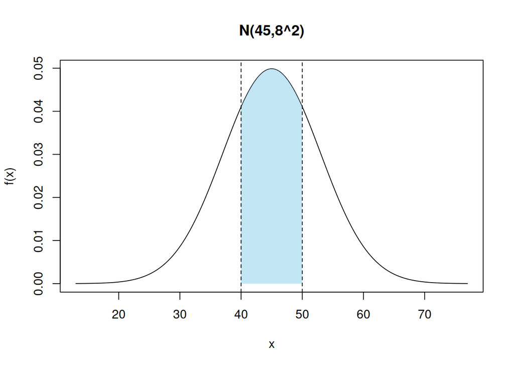

   ```r
       x <- seq(mu - 4*sigma, mu + 4*sigma, length.out = 500)

       y <- dnorm(x, mean = mu, sd = sigma)

       plot(
         x, y,
         type = "l",
         xlab = "x",
         ylab = "f(x)",
         main = "N(45,8^2)"
       )

       x_area <- seq(40, 50, length.out = 300)
       y_area <- dnorm(x_area, mean = mu, sd = sigma)

       polygon(
         c(40, x_area, 50),
         c(0, y_area, 0),
         col = adjustcolor("skyblue", alpha.f = 0.5),
         border = NA
       )

       abline(v = c(40, 50), lty = 2)
   ```

# Actividad 6: Exponencial

Sea $X \sim Exponencial(2)$, donde el tiempo está medido en miles de horas.

```r
  lamda <- 2
```

1. Calcula $P(X >0.5)$.

   ```r
   resultado <- pexp(0.5, lamda, FALSE)
   print(resultado)
   ```

   ```
   ## [1] 0.3678794
   ```

2. Calcula $P(X>1.2|x>0.7)$ utilizando la definición de probabilidad condicional.

   ```r
   P12 <- pexp(1.2, lamda, FALSE)
   P07 <- pexp(0.7, lamda, FALSE)
   resultado <- P12/P07
   print(resultado)
   ```

   ```
   ## [1] 0.3678794
   ```

3. Compara ambos resultados.

   ```r
   print(pexp(0.5, lamda, FALSE) == P12/P07)
   ```

   ```
   ## [1] TRUE
   ```

   Podemos ver que ambos resultados son iguales.
4. Explica con tus palabras qué significa la falta de memoria.

   La probabilidad de que ocurra un evento en un momento determinado es independiente de cuánto tiempo ya transcurrió.
5. Grafica la densidad exponencial y describe su forma.

[figure not shown]

   ```r
       x <- seq(0,2, length.out = 100)
       y <- dexp(x,lambda)

       plot(
         x, y,
         type = "l",
         xlab = "x",
         ylab = "f(x)",
         main = "Exponencial(2)"
       )
   ```

   La forma de la función indica que la probabilidad de ocurrencia de un evento es muy alta al principio del itervalo y va disminuyendo conforme avanza el tiempo.

# Actividad 7: Región y marginales

$$\begin{equation*}
A = \{(x,y):0<x<2/3, 1/3<y<2/3\}
\end{equation*}$$

1. Verifica matemáticamente que es una densidad válida.

$$\begin{align*}
\int \int f_{X,Y}(x,y) \ dy \ dx &= \int_0^{1} \int_{0}^{1} x+y\
dy\ dx\\
&= \int_0^{1} \left[ xy+\frac{y^2}{2} \right]_{0}^{1} dx \\
&= \int_0^{1} \left[ x(1)+\frac{(1)^2}{2} \right] dx \\
&= \int_0^{1} x+\frac{1}{2} dx \\
&= \left[ \frac{x^2+x}{2} \right]_0^{1} \\
&= \frac{1+1}{2} \\
&= 1
\end{align*}$$

2. Calcula $P((X,Y) \in A)$.

$$\begin{align*}
\int \int f_{X,Y}(x,y) \ dy \ dx &= \int_0^{2/3} \int_{1/3}^{2/3}
x+y\ dy\ dx\\
&= \int_0^{2/3} \left[ xy+\frac{y^2}{2} \right]_{1/3}^{2/3} dx \\
&= \int_0^{2/3} \left[
x(2/3)+\frac{(2/3)^2}{2}-x(1/3)-\frac{(1/3)^2}{2} \right] dx \\
&= \int_0^{2/3} \left[
\frac{2x}{3}+\frac{4}{18}-\frac{x}{3}-\frac{1}{18} \right] dx \\
&= \int_0^{2/3} \left[ \frac{x}{3}+\frac{1}{6} \right] dx \\
&= \frac{1}{6}\int_0^{2/3} 2x+1 \ dx \\
&= \frac{1}{6}\left[ x^2+x \right]_0^{2/3} \\
&= \frac{1}{6}\left[ (2/3)^2+(2/3) \right] \\
&= \frac{1}{6}\left[ 10/9 \right] \\
&= \frac{5}{27} =0.185 185 185
\end{align*}$$

3. Obtén $f_X(x)$.

$$\begin{align*}
f_X(x) &= \int f_{X,Y}(x,y) \ dy \\ &= \int_{0}^{1} x+y\ dy\
\\
&= \left[ xy+\frac{y^2}{2} \right]_{0}^{1} \\
&= x(1)+\frac{(1)^2}{2} \\
&= x+\frac{1}{2} \\
\end{align*}$$

4. Obtén $f_Y(y)$.

$$\begin{align*}
f_Y(y) &= \int f_{X,Y}(x,y) \ dx \\ &= \int_{0}^{1} x+y\ dx\
\\
&= \left[ \frac{x^2}{2}+xy \right]_{0}^{1} \\
&= y(1)+\frac{(1)^2}{2} \\
&= y+\frac{1}{2} \\
\end{align*}$$

5. Describe qué cambia respecto al caso de una sola variable aleatoria.

# Actividad Integradora

## Caso A: Conteo

Una máquina produce piezas con probabilidad de defecto $p = 0.08$. Se seleccionan $25$ piezas independientemente. Sea $X$ el número de piezas defectuosas.

Calcula:

$$\begin{equation*}
P(X\leq 3)
\end{equation*}$$

Sol:

En este caso tenemos que usar la distribución $Binom(n,p)$ con $n=25$ y $p=0.08$. Considerando el éxito como el evento “una pieza resulta defectuosa”, se nos pide calcular la probabilidad de que haya 3 o menos éxitos, esto en R se representa:

```r
  n = 25
  p = 0.08
  resultado <- pbinom(q = 3, size = n, prob = p, TRUE)
  print(resultado)
```

```
## [1] 0.8649078
```

Después calcula

$$\begin{equation*}
P(X > 5)
\end{equation*}$$

Seguiremos usando la distribución $Binom(n,p)$ con $n=25$ y $p=0.08$. En este caso se nos pide calcular la probabilidad de que más de 5 piezas sean defectuosas, entonces:

```r
  resultado <- pbinom(q = 5, size = n, prob = p, FALSE)
  print(resultado)
```

```
## [1] 0.01229271
```

## Caso B: Variable Continua

El tiempo de atención de un servicio se modela como:

$$\begin{equation*}
X \sim N(30,5^2)
\end{equation*}$$

Calcula:

$$\begin{equation*}
P(25<X<35)
\end{equation*}$$

Sol:

```r
mu <- 30
sigma <- 5
# P(25 < X < 35) = P(X < 35 ) - P(X <= 25)
resultado <- pnorm(35, mean = mu, sd = sigma, TRUE) - pnorm(25, mean = mu, sd = sigma, TRUE)
```

[output not shown]

Después grafica la densidad y representa visualmente la región correspondiente.

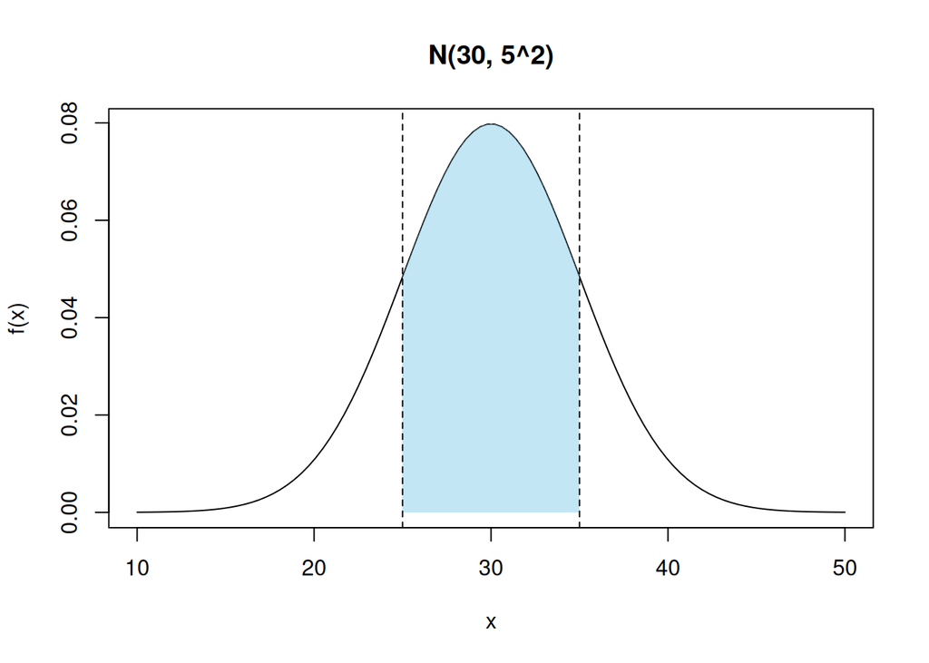

```r
    x <- seq(mu - sigma*4, mu+ sigma*4, length.out = 100)
    y <- dnorm(x, mean = mu, sd = sigma)


    plot(
      x, y,
      type = "l",
      xlab = "x",
      ylab = "f(x)",
      main = "N(30, 5^2)"
    )

    x_area <- seq(25, 35, length.out = 300)
    y_area <- dnorm(x_area, mean = mu, sd = sigma)

    polygon(
      c(25, x_area, 35),
      c(0, y_area, 0),
      col = adjustcolor("skyblue", alpha.f = 0.5),
      border = NA
    )


    abline(v = c(25, 35), lty = 2)
```

## Caso C: Tiempo de vida

Una variable $X$ tiene distribución exponencial con media 2 horas.

1. Determina $\lambda$.
2. Calcula $P(X>3)$.
3. Calcula $P(X>5|X>2)$.
4. Comprueba la propiedad de falta de memoria.